# Real-Time fMRI Analysis

Contributions

In typical fMRI experiments the researcher creates a sequence of stimuli or events they want to show in advance and then measures the participant's brain activity in response to this pre-specified task. This provides an assessment of the relationship between behavior in the task and BOLD activity. However, although tempting, it is not possible to conclude from this correlation alone that active brain regions are causing the behavior. Such causal inferences have typically required directly intervening to disrupt or enhance the functioning of a brain region (e.g., via stimulation, lesioning, cooling, etc.) and then examining the impact on behavior. Such experimental manipulations of brain function, especially in a regionally specific way, require invasive techniques and so are not possible in healthy humans for ethical reasons.

Real-time fMRI is a step in the direction of (safely) manipulating brain regions, enabling more valid causal inferences about the brain and behavior. Specifically, rather than brain activity being just a dependent variable, it becomes part of the experimental design as a kind of independent variable. For more on real-time fMRI, see [here](https://doi.org/10.1177/1073858411407205) or [here](https://www.nature.com/articles/nrn.2016.164).

Take for instance a recent study using real-time fMRI to train attention [deBettencourt et al. (2015)](http://ntblab.yale.edu/wp-content/uploads/2015/03/deBettencourt_NN_2015.pdf). In this study, patterns of brain activity were used to make the task easier or harder depending on the participant's attentional state, with the goal of training them to attend better. However, if the brain activity was too noisy or analyzed inappropriately, read out from brain regions that didn't contain information about attentional state, or taken from another participant's brain (as in the control condition), then the participant should not improve.

There are no second chances with real-time fMRI because your analysis is part of data collection. For example, you can't later decide to use a different preprocessing step, analysis algorithm, parameter setting, feedback type, etc. This is why preparation, piloting, and efficient code is critical for real-time fMRI. Think of it as mandatory pre-registration!

There are many different types of real-time fMRI, but here we focus on using the multivariate methods from earlier notebooks to analyze data on the fly and generate feedback for participants in a closed-loop manner.

## Goal of this script

```
1. Learn to design a multivariate real-time fMRI experiment
2. Run a real-time fMRI analysis using simulated data
```

1. The real-time workflow

> 1.1. Data file preparation  
> 1.2. File watcher  
> 1.3. Preprocessing a volume  
> 1.4. Training a model  
> 1.5. Classifying new volumes  
> 1.6. Modifying stimuli for feedback

2. Running a real-time simulation

3. Adaptive real-time experiments

Exercises

> 1 2 3 4 5 6 7 8  
> Novel contribution

## 1. The real-time workflow

The following sequence of steps are necessary for successfully running a real-time fMRI analysis.

1. Data file preparation: Setup a folder where fMRI volumes will be stored as they are created.
2. File watcher: A function that looks for a volume to process.
3. Preprocessing a volume: Preprocess the TR to prepare it for classification.
4. Training a model: Take the data you have set aside for training and create your classifier model.
5. Classifying new volumes: Take an epoch of data and classify that, assigning it a label.
6. Modifying stimuli for feedback The classifier results influence the next stimulus shown to the participant.

Here is an example pipeline from deBettencourt et al. (2015):

[figure not shown]

```python
import os
import time
import numpy as np  # type: ignore
import matplotlib.pyplot as plt
%matplotlib inline
from sklearn.linear_model import LogisticRegression  # type: ignore
from watchdog.events import PatternMatchingEventHandler  # type: ignore
from watchdog.observers import Observer  # type: ignore
from queue import Queue
from sklearn import svm
from sklearn import linear_model
import scipy.stats
from IPython import display
import shutil
from utils import results_path
```

### 1.1 Data file preparation

As you know, an fMRI data volume is generated for each TR. The scanner outputs these files one-by-one in DICOM format. We will not cover here how to create a network link between your scanner and your analysis computer, but you can find example instructions for Siemens [here](https://yale.box.com/s/ko0geash2en18ksx1ntgz5m71nhe60ld). Once transferred to the analysis computer, you will first need to read the DICOM data into a numpy array. The code below will then process the numpy array. One way to read DICOM files into numpy is by using the package [dicom-numpy](http://dicom-numpy.readthedocs.io/en/latest/).

For this notebook, we will generate simulated data using the BrainIAK [fmrism module](http://brainiak.org/docs/brainiak.utils.html?highlight=fmrisim#module-brainiak.utils.fmrisim). The function *generate_data.py* simulates a two condition experiment where each condition is blocked for 10s with no gap between events. This function simulates fMRI noise and then inserts signal in two regions corresponding to the two conditions with the appropriate hemodynamic response function.

**Self-Study:** Investigate the *generate_data.py* function to learn how it is working and what brain activity distinguishes between conditions.

**Exercise 1:** How is *generate_data.py* deciding the order of the two conditions? Is this how you would design an fMRI study? If not, modify the script to what you think is a better design.

**A:**

To simulate real-time data, this function outputs a TR every 2 s and saves it as a numpy matrix in the *fmrisim/data/* folder. To run the script, run the cell below.

```python
# Run the generate_data function
if shutil.which('sbatch') is not None:
    !sbatch ./13-real-time/run_generate_data.sh
else:
    %run ./13-real-time/generate_data.py
```

```
Submitted batch job 11358192
```

Any time you want to simulate the acquisition of data you should delete the contents of this folder (`rm 13-real-time/fmrisim/data/*`) and then run it again.

Below we will set the paths to be used. We also want to specify the proportion of trials that will be used for training the model (time until the real-time neurofeedback kicks in).

```python
data_dir = os.path.join(results_path, '13-real-time/data/')  # Where is information stored that is needed for generating data
file_pattern = 'rt_{0:0>3}.npy'  # What is the pattern of file that wil be created

train_count = 40  # Number of trials that will be used for training.
```

### 1.2 File watcher

For real-time fMRI, we need to monitor as every TR comes in. The simple way to do this is to just set up a loop that checks whether the file exists and waits until it does.

```python
# Create a file watching algorithm
def tr_watcher_simple(filename,
                      sleep_time=0.1,  # temporal resolution of the file watcher
                     ):

    # While the file doesn't exist, loop and wait
    while not os.path.exists(filename):
        time.sleep(sleep_time)  # How long do you want to wait for

    # When the file exists, load it and output it
    vol = np.load(filename)

    return vol
```

However, this procedure is inefficient and prone to error. For instance, if a volume is added just after a check, this code waits the sleep time before checking again. Moreover, this procedure can crash since the file names often exist before the file contents are created.

Instead, to process volumes as soon as they are finished being created, a file watcher function continuously polls for new files. Once a new file is found, it is added to a queue and triggers a call to the next processing step. The [watchdog package](https://pythonhosted.org/watchdog/) is used for ths purpose.

```python
# Create a file watching algorithm
def tr_watcher(filename, file_queue):

    # Does the file exist?
    file_exists = os.path.exists(filename)

    # While the file doesn't exist, loop and wait
    while not file_exists:

        # look for file creation event
        event = file_queue.get()

        # If there is an event then save it
        if event.src_path == filename:
            file_exists = True

    # When the file exists, load it and output it
    vol = np.load(filename)

    return vol


# Create a class of events for
class file_notify_handler(PatternMatchingEventHandler):

    # Initialize the object being created
    def __init__(self, queue, file_pattern):
        super().__init__(patterns=file_pattern)
        self.q = queue

    # When an event occurs, put it in the queue
    def on_created(self, event):
        self.q.put(event)
```

We are going to check out this file watcher in action. Remember to clear your `13-real-time/fmrisim/data` directory and re-launch *run_generate_data.sh*. This script will first play catch up and then print every time a new TR comes in until the training set is acquired.

```python
file_observer = Observer()
file_queue = Queue()  # type: ignore

# set up the notifications for when a new TR is created
notify_file_pattern = '*.npy'
file_notify = file_notify_handler(file_queue, [notify_file_pattern])
file_observer.schedule(file_notify, data_dir, recursive=False)
file_observer.start()

for idx in range(train_count):

    # What file name are you going to load
    next_filename = data_dir + file_pattern.format(idx)
    vol = tr_watcher(next_filename, file_queue)

    # When the file exists, load it and output it
    print('Recieved:', next_filename)

file_observer.stop()
```

```
Recieved: /usr/people/mk35/brainiak_results/13-real-time/data/rt_000.npy
Recieved: /usr/people/mk35/brainiak_results/13-real-time/data/rt_001.npy
Recieved: /usr/people/mk35/brainiak_results/13-real-time/data/rt_002.npy
Recieved: /usr/people/mk35/brainiak_results/13-real-time/data/rt_003.npy
Recieved: /usr/people/mk35/brainiak_results/13-real-time/data/rt_004.npy
Recieved: /usr/people/mk35/brainiak_results/13-real-time/data/rt_005.npy
Recieved: /usr/people/mk35/brainiak_results/13-real-time/data/rt_006.npy
Recieved: /usr/people/mk35/brainiak_results/13-real-time/data/rt_007.npy
Recieved: /usr/people/mk35/brainiak_results/13-real-time/data/rt_008.npy
Recieved: /usr/people/mk35/brainiak_results/13-real-time/data/rt_009.npy
Recieved: /usr/people/mk35/brainiak_results/13-real-time/data/rt_010.npy
Recieved: /usr/people/mk35/brainiak_results/13-real-time/data/rt_011.npy
Recieved: /usr/people/mk35/brainiak_results/13-real-time/data/rt_012.npy
Recieved: /usr/people/mk35/brainiak_results/13-real-time/data/rt_013.npy
Recieved: /usr/people/mk35/brainiak_results/13-real-time/data/rt_014.npy
Recieved: /usr/people/mk35/brainiak_results/13-real-time/data/rt_015.npy
Recieved: /usr/people/mk35/brainiak_results/13-real-time/data/rt_016.npy
Recieved: /usr/people/mk35/brainiak_results/13-real-time/data/rt_017.npy
Recieved: /usr/people/mk35/brainiak_results/13-real-time/data/rt_018.npy
Recieved: /usr/people/mk35/brainiak_results/13-real-time/data/rt_019.npy
Recieved: /usr/people/mk35/brainiak_results/13-real-time/data/rt_020.npy
Recieved: /usr/people/mk35/brainiak_results/13-real-time/data/rt_021.npy
Recieved: /usr/people/mk35/brainiak_results/13-real-time/data/rt_022.npy
Recieved: /usr/people/mk35/brainiak_results/13-real-time/data/rt_023.npy
Recieved: /usr/people/mk35/brainiak_results/13-real-time/data/rt_024.npy
Recieved: /usr/people/mk35/brainiak_results/13-real-time/data/rt_025.npy
Recieved: /usr/people/mk35/brainiak_results/13-real-time/data/rt_026.npy
Recieved: /usr/people/mk35/brainiak_results/13-real-time/data/rt_027.npy
Recieved: /usr/people/mk35/brainiak_results/13-real-time/data/rt_028.npy
Recieved: /usr/people/mk35/brainiak_results/13-real-time/data/rt_029.npy
Recieved: /usr/people/mk35/brainiak_results/13-real-time/data/rt_030.npy
Recieved: /usr/people/mk35/brainiak_results/13-real-time/data/rt_031.npy
Recieved: /usr/people/mk35/brainiak_results/13-real-time/data/rt_032.npy
Recieved: /usr/people/mk35/brainiak_results/13-real-time/data/rt_033.npy
Recieved: /usr/people/mk35/brainiak_results/13-real-time/data/rt_034.npy
Recieved: /usr/people/mk35/brainiak_results/13-real-time/data/rt_035.npy
Recieved: /usr/people/mk35/brainiak_results/13-real-time/data/rt_036.npy
Recieved: /usr/people/mk35/brainiak_results/13-real-time/data/rt_037.npy
Recieved: /usr/people/mk35/brainiak_results/13-real-time/data/rt_038.npy
Recieved: /usr/people/mk35/brainiak_results/13-real-time/data/rt_039.npy
```

### 1.3 Preprocessing a volume

As each volume is received, it is necessary to preprocess it prior to analysis. Given the constraint of wanting to do this as close as possible to real-time, you will need to choose steps carefully and decide on the minimal set of steps that provide the most benefit. For example, motion correction, masking, and normalization might be sufficient. The simulator does not generate any motion artifacts so that step is unnecessary in this notebook. Masking is critical because we don't want to feed the model irrelevant features. Normalization in space (as we will do) is easy because each time point can be treated independently; however, normalizing across time is hard since each additional TR will change the mean and SD, and thus the z-values of all preceding TRs. This is a more general consequence of real-time, wherein you know the past but not the future. This also impacts temporal filtering, which must be done with "causal" filters. For this reason, procedures for normalizing and filtering over time are still being developed/refined.

**Self-study:** Look into normalizing voxels across time. Helpful information is found in [StandardScaler](http://scikit-learn.org/stable/modules/generated/sklearn.preprocessing.StandardScaler.html). For temporal filtering, compare the [filtfilt](https://docs.scipy.org/doc/scipy-0.18.1/reference/generated/scipy.signal.filtfilt.html) and [lfilter](https://docs.scipy.org/doc/scipy-0.18.1/reference/generated/scipy.signal.lfilter.html) functions in scipy.

**Exercise 2:** Create a preprocessing function. This function will take in a volume and a mask, perform masking and then z-score the masked voxels in space, and then output a 1-dimensional vector of preprocessed voxels.

```python
# Insert code here
def preprocess_vol(vol, mask):
```

**Exercise 3:** Do a speed test of the file watcher and preprocessing functions to make sure they complete in less than 1 TR (here 2s). Specifically add to the starter code below appropriate time stamping and print commands.

```python
# Insert code here

# load mask
mask_file = data_dir +'mask.npy'
mask = np.load(mask_file)

# allocate a matrix to hold the TR data, preset to NaNs. Each row is a TR vector
tr_data = np.full((train_count, mask.sum()), np.nan)

# set up the notifications for when a new TR is created
file_observer = Observer()
file_queue = Queue()  # type: ignore

notify_file_pattern = '*.npy'
file_notify = file_notify_handler(file_queue, [notify_file_pattern])
file_observer.schedule(file_notify, data_dir, recursive=False)
file_observer.start()

# Cycle through TRs
for idx in range(train_count):

    # Start the timer

    # What file name are you going to load
    next_filename = data_dir + file_pattern.format(idx)
    vol = tr_watcher(next_filename, file_queue)

    # Store the volume as a preprocessed vector
    tr_data[idx, :] = preprocess_vol(vol, mask)

    # End the timer

    # Print the timing

file_observer.stop()
```

### 1.4 Training a model

After we have collected enough volumes we then train our classifier. Like [deBettencourt et al. (2015)](http://ntblab.yale.edu/wp-content/uploads/2015/03/deBettencourt_NN_2015.pdf) we will use an L2 regularized logistic regression. Below a function is created to take in time by voxel training data and a list of labels for each volume and then fit a regression function to it.

```python
# Train 2 Logistic Regression models
def train_logistic(training_data,
                   training_labels,
                   parameters='l2'):

    # Train the model predicting state 2 (so that true means 1 and false means 0)
    clf = LogisticRegression(penalty=parameters)
    clf.fit(training_data, training_labels == 2)

    return clf
```

A critical step when training the model is shifting the labels. We expect that a stimulus will evoke activity 4-6 s after its onset because of the hemodynamic lag?.

```python
# Load the labels
label_file = data_dir + 'labels.npy'
labels = np.load(label_file)

# How much do you need to shift the labels by in terms of TRs
tr_shift = 3

training_data   = tr_data[tr_shift:train_count, :]
training_labels = labels[0:train_count - tr_shift]
```

```python
# Fit the model
clf = train_logistic(training_data, training_labels[:,0])
```

We can now visualize this training in order to see what the model has learned.

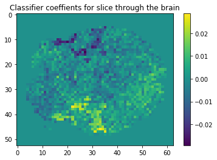

```python
coefs = np.zeros(mask.shape)
coefs[mask==1]=clf.coef_[0,:]

plt.imshow(coefs[:,:,16])
plt.title('Classifier coeffients for slice through the brain')
plt.colorbar()
```

### 1.5 Classifying new volumes

Now that we have trained a model, we can classify incoming volumes with the learned weights. Since most classifiers come with the *.fit* and *.predict* formulation in scikit-learn, this is very easy to do (after some reshaping). In the case of a logistic regression, the outcome is simply `True` or `False`. In this case, `True` means condition 2 and `False` means condition 1.

```python
# Get a new volume
next_filename = data_dir + file_pattern.format(train_count + 1)
vol = tr_watcher(next_filename, file_queue)

# Store the volume as a preprocessed vector
new_data = preprocess_vol(vol, mask)
prediction = clf.predict(new_data.reshape(1, -1))

print('Prediction for TR %d is condition %d and the label is %d' % (train_count + 1, prediction + 1, labels[idx - tr_shift]))
```

```
Prediction for TR 41 is condition 1 and the label is 1
```

### 1.6 Modifying stimuli for feedback

The final step of closed-loop multivariate real-time fMRI is to use the classifier results and provide feedback to the participant in the scanner. This could involve changing the composition of the stimulus, changing the task difficulty, or providing feedback directly via a scale or gauge. Although we won't do this here, such displays can be easily implemented in experiment code from [Psychtoolbox](http://psychtoolbox.org/) or [PsychoPy](http://www.psychopy.org/).

## 2. Running a real-time simulation

Now that we have all parts of the real-time workflow, we can put them together to run a simulated real-time experiment. The function below named `realtime` does this.

This takes as an input the `fmrisim` directory. It also takes the number of volumes that are used for training and a function that specifies how to run the classifier (e.g., `train_logistic`). The final input `incremental_batch` will be discussed later.

```python
def realtime(data_dir,
             train_count,
             clf_obj=train_logistic,
             incremental_batch=0,
            ):

    # While the file doesn't exist, loop and wait
    label_file = data_dir + 'labels.npy'
    while not os.path.exists(label_file):
        time.sleep(0.1)  # How long do you want to wait for

    # load labels
    labels = np.load(label_file)

    # How much do you need to shift the labels by in terms of TRs
    tr_shift = 3

    # load mask
    mask_file = data_dir +'mask.npy'
    mask = np.load(mask_file)

    # allocate a matrix to hold the TR data, preset to NaNs. Each row is a TR vector
    tr_data = np.full((len(labels), mask.sum()), np.nan)

    # Set up the figure
    plt.figure()  # Set up figure
    plt.plot((train_count, train_count), (0, 3), 'g')
    plt.xlim((0, len(labels)))
    plt.ylim((0, 3))
    plt.title('Searching for the first TR')
    is_print=0

    # set up the notifications for when a new TR is created
    file_observer = Observer()
    file_queue = Queue()  # type: ignore

    file_notify = file_notify_handler(file_queue, [notify_file_pattern])
    file_observer.schedule(file_notify, data_dir, recursive=False)
    file_observer.start()

    # Listen for TRs
    num_correct = 0  # Preset the number of correct answers to zero
    for idx in range(len(labels)):

        # What file name are you going to load
        next_filename = data_dir + file_pattern.format(idx, '02d')
        vol = tr_watcher(next_filename, file_queue)

        # Store the volume as a preprocessed vector
        tr_data[idx, :] = preprocess_vol(vol, mask)

        plt.plot(range(idx), labels[0:idx], 'r-')

        # Collect TRs for training
        if idx < train_count:
            plt.title('TR: %d for training' % idx)
        elif idx == train_count: # Is this time to train the classifier

            # Train the classifier
            trainStart = time.time()
            plt.title("Sufficient TRs collected, training the model")

            # Train the classifier
            clf = clf_obj(tr_data[tr_shift:train_count, :], labels[0:train_count - tr_shift][:,0])

            # Report the training duration
            print("Completed training in %0.2f sec" % (time.time() - trainStart))

        elif idx > train_count:  # Is this after training (is it testing)

            # Pull out the predictions of the model for this TR
            prediction = clf.predict(tr_data[idx, :].reshape(1, -1))

            # If it is a boolean (0 or 1) then add 1 to turn it into the labels
            if prediction.dtype=='bool':
                prediction = prediction + 1

            if prediction == labels[idx - tr_shift]:
                num_correct += 1

            plt.scatter(idx, prediction)
            accuracy = num_correct / (idx - train_count)
            plt.title('TR: %d; Total accuracy: %0.2f' % (idx + 1, accuracy))

            # Do you want to create a new batch for training if doing an incremental fit
            if incremental_batch > 0 and np.mod((idx - train_count), incremental_batch) == 0:

                # When does this batch start
                start_idx = idx - incremental_batch

                # Feed in the classifier to be updated with the current batch size
                clf = clf_obj(tr_data[start_idx + tr_shift:idx, :], labels[start_idx:idx - tr_shift], clf)

                # Mark where the new batch was loaded in
                plt.plot((idx, idx), (0, 3), 'k')

        # Plot the figure
        display.clear_output(wait=True)
        display.display(plt.gcf())
        plt.xlim((0, len(labels)))
        plt.ylim((0, 3))

    # Stop listening
    file_observer.stop()

    # Return the accuracy overall
    return accuracy
```

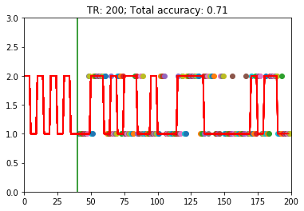

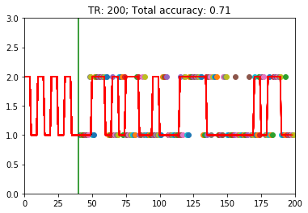

```python
try:
    realtime(data_dir=data_dir,
             train_count=train_count,
             clf_obj=train_logistic,
             incremental_batch=0,
            )
except Exception as err:
    file_observer.stop()
    print("Exception: {}".format(err))
```

**Exercise 4:** Re-run the `realtime` function using a different classifier. Create a new classifier function with a different kernel and run it below.

```python
# Insert new classifier object
```

```python
# Run the realtime function with this new classifier object
```

**Exercise 5:** Create a new copy of the `realtime` function below and rename it. Then edit it in order to plot the classifier decision evidence rather than the labels. Make sure that you have an appropriate classifier that outputs the decision evidence for each prediction (and re-scale your figure appropriately).

```python
# Insert code below
```

## 3. Adaptive real-time experiments

The goal of real-time fMRI is often to change brain function via neurofeedback. For instance, neural representations might change because the experiment trains participants to use different parts of their brain to process a stimulus. In such cases, a classifier trained at the start of the experiment will be wrong by the end of the experiment because the underlying feature space across voxels in the brain has changed. There are algorithms that can be used in these cases, which allow the model fit to be updated incrementally as new training examples come in. This can also be used to refine your model with more training data even if the underlying features are stable.

This approach to dynamically training classifiers is called incremental or online learning and [scikit-learn](http://scikit-learn.org/stable/modules/scaling_strategies.html#incremental-learning) has a number of classifiers that allow this. Below we specify one classifier with this functionality. First we will run it without incremental updating as a baseline.

Beware: The initialization of these functions can have a dramatic effect on performance, which you can evaluate by using a random seed.

```python
def train_incremental(training_data,
                      training_labels,
                      parameters=None,
                     ):

    all_classes = np.array([1, 2])  # Need to say all the labels, in case you want to test out of sample

    # Get the clf
    if parameters is None:
        # Create the linear if it hasn't already been passed in by parameters
        clf = linear_model.SGDClassifier()
    else:
        clf = parameters  # Pull out the classifier

    # Fit the training data (either initializing the clf or updating it)
    clf.partial_fit(training_data,
                    training_labels,
                    classes=all_classes,
                   )

    return clf
```

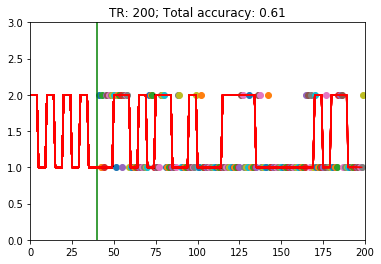

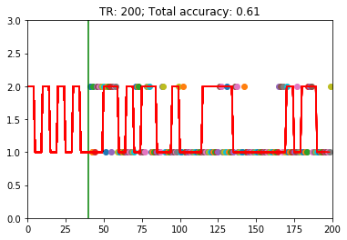

```python
try:
    np.random.seed(0)
    realtime(data_dir=data_dir,
             train_count=train_count,
             clf_obj=train_incremental,
             incremental_batch=0,
            )
except Exception as err:
    file_observer.stop()
    print("Exception: {}".format(err))
```

```python
try:
    np.random.seed(0)
    realtime(data_dir=data_dir,
                   train_count=train_count,
                   clf_obj=train_incremental,
                   incremental_batch=40,
                  )
except Exception as err:
    file_observer.stop()
    print("Exception: {}".format(err))
```

[output not shown]

**Exercise 6:** Adjust the size of the batch that you use to re-train the model. What are the advantages of using a small vs. large batch? What batch size that you tried works best and why?

**A:**

Now that we have a classifier that can update its weights dynamically, we will perform a simulation in which the responses in the fMRI data change part way through the study. The `generate_data.py` script allows this with a few parameter changes.

**Exercise 7:** Simulate new data where the brain areas that discriminate between conditions switch halfway through the run. Hint: look at the parameters in `generate_data.py`.

```python
# Insert code here
```

**Exercise 8:** Run a real-time analysis on this new dataset with and without incremental learning (using the optimal batch size from above) and compare the results.

```python
# Insert code here
```

Take this to the next level by doing a parameter search over the different combinations of parameters.

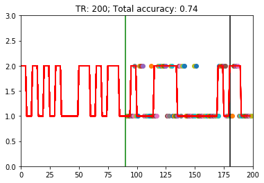

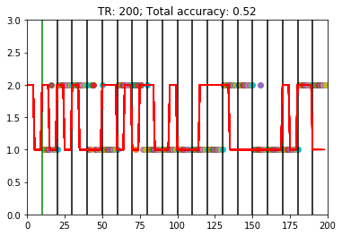

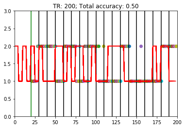

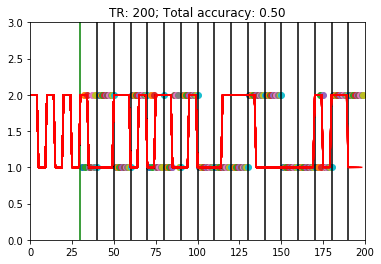

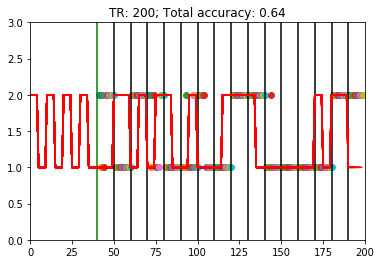

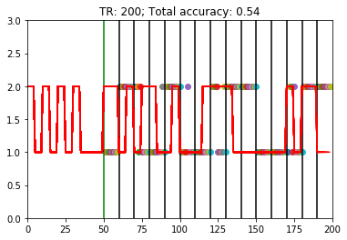

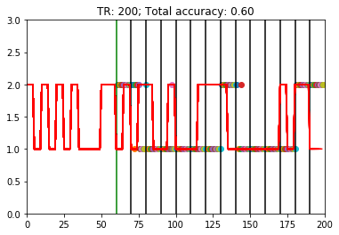

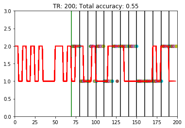

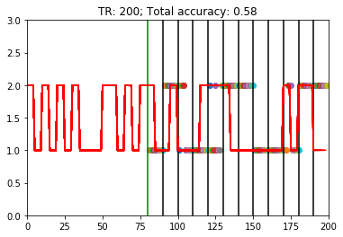

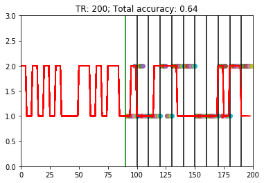

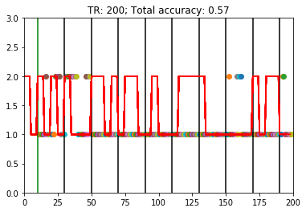

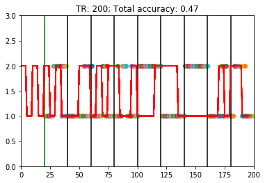

[69 more figures not shown]

```python
batch_values = range(10, 100, 10)
train_values = range(10, 100, 10)
results = np.zeros((len(batch_values), len(train_values)))
for batch_counter in range(len(batch_values)):
    for train_counter in range(len(train_values)):

        # Pull out the values
        batch_size = batch_values[batch_counter]
        train_size = train_values[train_counter]

        np.random.seed(0)
        result = realtime(data_dir=data_dir,
                          train_count=train_size,
                          clf_obj=train_incremental,
                          incremental_batch=batch_size,
                         )

        # Store the results
        results[batch_counter, train_counter] =  result
```

[figure not shown]

```python
# We can visualize this parameter search by making a heat map
plt.figure(figsize = (12,8))
plt.imshow(results, interpolation = 'none')
plt.xlabel("Incremental batch value")
plt.ylabel("# TRs used for training")
plt.title("Heatmap of SDG classification accuracy with different input parameters")
```

**Novel contribution:** Be creative and make one new discovery by adding an analysis, visualization, or optimization.

Here are some ideas:

- Build a real-time experiment with more than two classes e.g. for three classes you could use Faces, Places, and Objects.
- Use GridSearch to find optimal hyper-parameters in real-time.

### Contributions

G. Wallace for providing initial code.  
M. Kumar, C. Ellis and N. Turk-Browne produced the initial notebook 04/2018.  
G. Wallace enabled execution in non cluster environments.